# Project 2

Nisha Depala (s2149899)

# 1 3D printer

We consider two linear models, A and B, to capture the relationship between CAD weight $(x_i)$ and actual weight $(y_i)$. The models are defined as
$$\text{Model A: } y_i \sim
\text{Normal}[\beta_1 + \beta_2x_i, exp(\beta_3+\beta_4x_i)] \text{ and
Model B: } y_i \sim \text{Normal}[\beta_1 + \beta_2x_i,
exp(\beta_3)+(\beta_4)x_i^2]$$

## 1.1 Probabilistic predictions

```r
A_fit <- filament1_estimate(filament1, "A")
B_fit <- filament1_estimate(filament1, "B")

pred_A <- filament1_predict(filament1, A_fit)
pred_B <- filament1_predict(filament1, B_fit)

pred_A$Actual_Weight <- filament1$Actual_Weight
pred_B$Actual_Weight <- filament1$Actual_Weight

CAD_Weight <- filament1$CAD_Weight
```

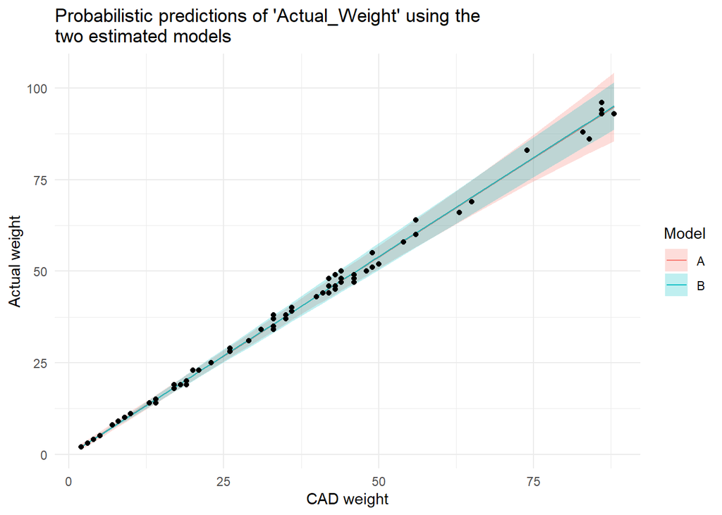

Looking at the graph, we can see that plotting `CAD_Weight` against `Actual_Weight` closely follows a linear relationship. This is expected as both of the models are linear; the points on the plot do not follow a perfectly linear relationship with some of the points deviating from the center.

As we have used a 5% level of significance to compute prediction intervals for both models, we can draw direct comparisons. The prediction intervals for both of the models are relatively narrow which indicates more confidence in the predictions for the actual weight of the objects being printed. Both of the ribbons also contain the vast majority of the objects indicating that it is a close fit and there is a good model performance.

Model A has slightly wider prediction intervals than model B which indicates that the actual weight predictions from model B have a higher level of confidence in those predictions.

## 1.2 Leave-one-out cross-validation (LOOCV)

Let us complement this with quantitative data by looking at the squared error (ES) and Dawid-Sebastiani (DS) scores:

```r
scoreA <- leave1out(filament1, "A")
scoreB <- leave1out(filament1, "B")
```

’’’ NB: The `leave1out()`function calculates the number of observations in the data set and then adds columns for the predictive mean and standard deviation to the set. It then iterates through each observation, known as the validation set, leaving one out at a time and fits the model on the remaining data, known as the training data. It predicts the outcome by using the function `filament1_predict()` which gives the predicted mean and standard deviation. It then calculates the ES and DS scores for each observation.

LOOCV can help to reduce both bias and variance in machine learning models by providing an estimate of the model’s performance on new data.

By training the model on all but one of the data points, LOOCV provides a more accurate estimate of the model’s performance than traditional cross-validation methods.

In addition, LOOCV can help to identify whether a model has high bias or high variance. If a model has high bias, LOOCV will typically result in similar performance on each iteration, as the model is not able to capture the true patterns in the data. On the other hand, if a model has high variance, LOOCV will typically result in a wider range of performance on each iteration, as the model is highly sensitive to small fluctuations in the training data. By identifying whether a model has high bias or high variance, it is possible to adjust the model accordingly to improve its performance. ’’’

Errors for models A and B

| Model | Squared Error | Dawid-Sebastiani |
| --- | --- | --- |
| A | 1.841734 | 1.128348 |
| B | 1.841995 | 0.939715 |

The ES calculates the average of the difference between the actual and predicted values. This is a particularly useful method in evaluating whether our models are good fits or not as it gives more weight to the large errors making them more pronounced, thus leading to a higher ES score. For both model A and model B, the ES score is the same to 3 s.f. which implies that the uncertainty in both of the models is similar. A score of $1.842$ (3 s.f.) is low in context with the range of `CAD_Weight` which indicates that the models are a good fit for `filament1.rda`. This supports the conclusions drawn from the graph above.

The DS score measures the accuracy of probabilistic predictions by considering both the mean and the uncertainty of the predictions. It allows for a deeper understanding of how accurate the predicted actual weights calculated are. A lower score indicates that our predicted values are close to the mean (the line of best fit displayed on the graph) and the standard deviation is minimised. This means that whilst model A and model B have similar DS scores, model B is more accurate as a model for predicting the actual weights for the 3D printer. This also complements the comments made above from the visual interpretation of the graph.

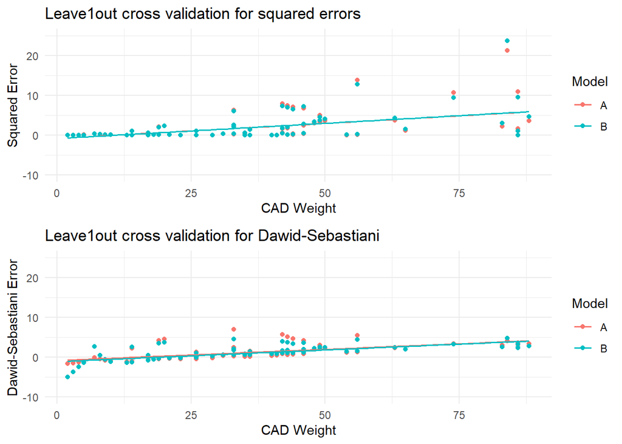

Each point on these plots represents the individual prediction for the CAD weight of the object printed by the 3D printer against its score. This allows for us to see how the score varies as the size of the object increases for each model.

For the squared error score, we can see that the predicted actual values for both objects closely mirror each other. This shows that there is a discrepancy between the lighter and heavier weights with the heavier weights deviating further from the line of best fit. This indicates that the model has a larger squared error score for larger objects. This, however, does make sense as the score has to be considered relatively and as the size of the object being printed is larger, the error must also grow proportionally.

## 1.3 Monte Carlo estimate

$H_0:$ The predictions from model A and model B are exchangeable.

$H_1:$ The predictions from model B are better than the predictions from model A.

```r
# Calculate score difference between models A and B
score_diff <- data.frame(se = score_AB$se_A - score_AB$se_B,
                         ds = score_AB$ds_A - score_AB$ds_B)

# Calculate mean score differences for the observed data
statistic0 <- score_diff %>% summarise(se = mean(se), ds = mean(ds))

# Number of iterations for Monte Carlo simulation
J <- 10000

statistic <- data.frame(se = numeric(J),
                        ds = numeric(J))

# Perform Monte Carlo simulation
for (loop in seq_len(J)) {
  # Generate random signs to add noise
  random_sign <- sample(c(-1, 1), size = nrow(score_diff), replace = TRUE)

  # Compute simulated statistics using the random signs
  statistic[loop, ] <- score_diff %>% summarise(se = mean(random_sign * se),
                                                ds = mean(random_sign * ds))
}

# Calculate p-values for ES and DS
p_values <-
  statistic %>%
  summarise(se = mean(se > statistic0$se),
            ds = mean(ds > statistic0$ds))

# Calculate Monte Carlo standard errors
mc <- c(sqrt((p_values$se * (1 - p_values$se)) / J),
        sqrt((p_values$ds * (1 - p_values$ds)) / J))
```

This code is a procedure to assess the statistical significance of the differences between the two models using Monte Carlo simulation. The p-values obtained can help determine if the observed differences are statistically significant.

P-values for different errors

|  | Monte Carlo estimate p-value | Monte Carlo standard error |
| --- | --- | --- |
| Squared Error | 0.4989 | 0.005000 |
| Dawid-Sebastiani | 0.0436 | 0.002042 |

The Monte Carlo Estimate p-value for the squared error is $0.4989$, which indicates that there is insufficient evidence to reject the null hypothesis of model A or model B being exchangeable. Both models seem to perform the same way in terms of prediction accuracy in terms of its squared error.

# 2 Archaeology in the Baltic sea

At the gravesite in Gotland, in the field outside the walls of Visby, a total of 493 femurs were found. The femurs consisted of 256 left femurs and 237 right femurs which means that at least 256 people must have been buried there.

To try and see how many people were actually buried there, we can build a simple model which takes a vector $y$, of independent observations from a $\text{Bin}(N, \phi)$ distribution. Here, $N$ is the total number of people buried and $\phi$ is the probability of finding a left or right femur. Both of these values are unknown.

The probability function for a single observation $y \sim \text{Bin}(N,\phi)$ is
$$p(y \mid N, \phi) = {N \choose y}
\phi^y(1-\phi)^{N-y}.$$

The combined log-likelihood $\ell(y_1,y_2 \mid N, \phi) = \log p(y_1, y_2 \mid N, \phi)$ for the data set $\{y_1,y_2\}$ is then given by

$$\begin{align*}
\ell(y_1,y_2 \mid N, \phi) = &-\log\Gamma(y_1+1)-\log\Gamma(y_2+1)
\\
&-\log\Gamma(N-y_1+1)-\log\Gamma(N-y_2+1)+2\log\Gamma(N+1) \\
&+ (y_1+y_2)\log(\phi)+(2N-y_1-y_2)\log(1-\phi)
\end{align*}$$

Before the excavation took place, the archaeologist believed that around 1000 individuals were buried, and that they would find around half on the femurs. To encode that belief in the Bayesian analysis, we set $\xi = 1/(1+ 1000)$, which corresponds to an expected total count of 1000, and $a = b = 1/2$, which makes $\phi$ more likely to be close to $1/2$ than to $0$ or $1$.

Monte Carlo integration can be used to estimate the posterior expectations of $N$ and $\phi$. Consider prior distributions $N \sim \text{Geom}(\xi), \quad0<\xi<1,$ and $\phi \sim \text{Beta}(a,b),\quad a,b>0$. We consider the prior distributions as sampling distributions for the Monte Carlo integrations, such that samples $n^{[k]}\sim \text{Geom}(\xi)$ and $\phi^{[k]}\sim \text{Beta}(a,b)$, can be used to compute Monte Carlo estimates:

```r
y = c(237, 256)
xi = 1/1001
a = 1/2
b = 1/2
K = 10000

estimates <- as.data.frame(estimate(y, xi, a, b, K))
```

|  | $\widehat p_{\mathbf{y}}(\mathbf{y})$ | $\widehat E (N \mid \mathbf{y})$ | $\widehat E (\phi \mid \mathbf{y})$ |
| --- | --- | --- | --- |
| Monte Carlo estimates | 7.9e-06 | 981.9492 | 0.3741221 |

The first posterior expectation represents the average value of the total number of people buried given the observed data. This number is very close to $1000$ which means that according to the model, around $981$ people were buried here.

The second posterior expectation represents the average probability of finding a left or right femur. This implies that there is approximately a $37.4\%$ chance of finding a femur.

This model does not appear to be a good fit but this could be due to a variety of reasons. The record keeping during the battle was poor and so the number of people calculated would not necessarily be accurate. If the model is based off this, then it makes sense that whilst the posterior expectations match up, it wouldn’t necessarily be a good fit as the marginal likelihood is very very small. It is important to consider the uncertainty associated with these estimates, for example by calculating credible intervals to gain a more valuable understanding of the dataset.

# 3 Code appendix

```r
#' Nisha Depala, s2149899
#' Add your own function definitions on this file.

#' neg_log_lik
#
#' @description Evaluate the negated log-likelihood for model A and B
#' @param beta A vector with the beta parameters
#' @param data A `data.frame` with the same variables as the `filament1` data set.
#' Must have columns `CAD_Weight` and `Actual_Weight`
#' @param model Either "A" for a log-linear variance model, or "B" for a proportional
#' scaling error model

neg_log_lik <- function(beta, data, model){

  mu <- beta[1] + beta[2]*data[["CAD_Weight"]]

  # distinguish between the two models to find the particular standard deviation for the betas
  if(model == "A") {
    sigma <- sqrt(exp(beta[3] + beta[4]*data[["CAD_Weight"]]))
  }else{
    sigma <- sqrt(exp(beta[3])+exp(beta[4]) * (data[["CAD_Weight"]]^2))
  }
  - sum(dnorm(data[["Actual_Weight"]],
              mean = mu,
              sd=sigma,
              log = TRUE))

}

#' filament_estimate
#
#' @description Estimate filament models with different variance structure
#' @param data A `data.frame` with the same variables as the `filament1` data set.
#' Must have columns `CAD_Weight` and `Actual_Weight`
#' @param model Either "A" for a log-linear variance model, or "B" for a proportional
#' scaling error model
#' @return An estimation object suitable for use with [filament1_predict()]

filament1_estimate <- function(data, model) {
  model <- match.arg(model, c("A", "B"))
  if (model == "A") {
    beta_start <- c(-0.1, 1.07, -2, 0.05)
  } else {
    beta_start <- c(-0.15, 1.07, -13.5, -6.5)
  }
  opt <- optim(beta_start,
               neg_log_lik,
               data = data,
               model = model,
               hessian = TRUE,
               method = "Nelder-Mead",
               control = list(maxit = 5000)
  )
  fit <- list(
    model = model,
    par = opt$par,
    hessian = opt$hessian
  )
  class(fit) <- c("filament1_estimate", "list")
  fit
}

#' filament1_aux_EV
#'
#' @description Evaluate the expectation and variance for model A and B
#' @param beta A vector with the beta parameters
#' @param data A `data.frame` containing the required predictors, including `CAD_Weight`
#' @param model Either "A" for a log-linear variance model, or "B" for a proportional
#' scaling error model
#' @param Sigma_beta : If not NULL, an estimate of the covariance matrix for
#                 the uncertainty of estimated betas
#' @return A list with four elements:
#     E : E(y|beta,x)
#     V : Var(y|beta,x)
#     VE : Var(E(y|beta,x)|x) or NULL
#     EV : E(Var(y|beta,x)|x) or NULL

filament1_aux_EV <- function(beta, data, model = c("A", "B"),
                             Sigma_beta = NULL) {

  model <- match.arg(model)
  if (model == "A") {

    ZE.0 <- model.matrix( ~ 1 + CAD_Weight, data = data)
    ZV.0 <- model.matrix( ~ 1 + CAD_Weight, data = data)
    ZE = cbind(ZE.0, ZV.0 * 0)
    ZV = cbind(ZE.0 * 0, ZV.0)

    VE <- EV <- NULL
    if (!is.null(Sigma_beta)) {
      # E(Var(y|beta,x)|x)
      EV <- exp(ZV %*% beta + rowSums(ZV * (ZV %*% Sigma_beta)) / 2)
      # Var(E(y|beta,x)|x)
      VE <- rowSums(ZE * (ZE %*% Sigma_beta))
    }
    out <- list(
      E = ZE %*% beta,
      V = exp(ZV %*% beta),
      VE = VE,
      EV = EV
    )
  } else {

    ZE.0 <- model.matrix( ~ 1 + CAD_Weight, data = data)
    ZV.0 <- model.matrix( ~ 1 + I(CAD_Weight^2), data = data)
    ZE = cbind(ZE.0, ZV.0 * 0)
    ZV = cbind(ZE.0 * 0, ZV.0)

    VE <- EV <- NULL
    if (!is.null(Sigma_beta)) {
      # E(Var(y|beta,x)|x)
      # (pmin: Ignore large Sigma_beta values)
      EV <- ZV %*% exp(beta + pmin(0.5^2, diag(Sigma_beta)) / 2)
      # Var(E(y|beta,x)|x)
      VE <- rowSums(ZE * (ZE %*% Sigma_beta))
    }
    out <- list(
      E = ZE %*% beta,
      V = ZV %*% exp(beta),
      VE = VE,
      EV = EV
    )
  }
  out
}

#' filament1_predict
#'
#' @description Computes predictive distributions and 95% confidence intervals for a dataset.
#' @param new_data The new dataset we want to make predictions for.
#' @param filament_fit Estimated parameters for a given model using filament1_estimate.
#'
#' @return a data frame with 4 variables summarising the predictive distribution for each row of the new data:
#'    mean: E(y|beta,x)
#'    sd: sqrt(Var(y|beta,x))
#'    lwr: lower predictive interval
#'    upr: upper predictive interval
#'
#' @seealso filament1_aux_EV,  filament1_estimate
#'
#' @examples
#' # Assuming 'new_data' is a data frame with predictor variables,
#' # and 'filament_fit' is the model fit object obtained from filament1_estimate
#' A_fit <- filament1_estimate(filament1, "A")
#' pred_A <- filament1_predict(filament1, A_fit)

filament1_predict <- function(new_data, filament_fit){
  # extract model and parameters from filament_fit
  model <- filament_fit$model
  beta <- filament_fit$par
  sig_b <- solve(filament_fit$hessian)

  # Calculate expected value and variance
  aux_ev <- filament1_aux_EV(beta, new_data, model, sig_b)

  # Extract predictive mean and standard deviation
  mean <- aux_ev$E
  sd <- sqrt(aux_ev$EV + aux_ev$VE)

  # Calculate z for 95% confidence interval
  z <- qnorm(0.975)

  # Calculate lower and upper predictive intervals
  lwr <- mean - z * sd
  upr <- mean + z * sd

  result <- data.frame(mean, sd, lwr, upr)

  return(result)
}

#' se
#'
#' @description Computed the squared error between predicted and actual values
#'
#' @param pred A numeric vector of predicted values.
#' @param act A numeric vector of actual values.
#'
#' @return A numeric vector of squared errors between predicted and actual values.
#'
#' @examples
#' # Assuming 'pred' and 'act' are vectors
#' squared_error <- se(pred, act)
#'
#' @export

se <- function(pred, act){
  se <- (pred - act)^2
  return(se)
}

#' ds
#'
#' @description Computes the Dawid-Sebastiani score
#'
#' @param pred_mean A numeric vector of predicted mean.
#' @param pred_sd A numeric vector of predicted standard deviation.
#' @param act_mean A numeric vector of actual values.
#'
#' @return A numeric vector containing the Dawid-Sebastiani score.
#'
#' @examples
#' # Assuming 'pred_mean', 'pred_sd' and 'act_mean' are vectors
#' dawid_sebastiani <- (pred_mean, pred_sd, act_mean)
#'
#' @export

ds <- function(pred_mean, pred_sd, act){
  ds <- (pred_mean - act)^2 / (pred_sd^2) + 2 * log(pred_sd)
  return(ds)
}

#' leave1out
#'
#' @description Performs leave-one-out cross validation for a given model and dataset.
#'
#' @param data The dataset for which leave-one-out cross validation is performed.
#' @param model The model used for estimation and prediction, "A" or "B".
#'
#' @return A modified dataset with columns added for predictive mean, predictive standard deviation, squared error, and deviance statistic for each observation.
#'
#' @examples
#' # Assuming 'data' is a data frame with predictor and response variables, and 'model'
#' result <- leave1out(data, model)
#' head(result)
#'
#' @seealso filament1_estimate, filament1_predict.
#'
#' @export

leave1out <- function(data, model) {
  # Number of observations
  n <- nrow(data)

  # Add columns for predictive mean and standard deviation
  data <- data %>%
    mutate(mean = NA_real_, sd = NA_real_)

  # Execute leave1out cross validation
  for (i in 1:n) {
    # Exclude i-th observation in fit
    fit <- filament1_estimate(data[-i, , drop = FALSE], model)

    # Predict i-th observation
    pred <- filament1_predict(data[i, , drop = FALSE], fit)

    data[i, "mean"] <- pred$mean
    data[i, "sd"] <- pred$sd
  }

  # Calcuate squared error and Dawid-Sebastiani statistic
  data <- data %>%
    mutate(se = se(mean, data$Actual_Weight),
           ds = ds(mean, sd, data$Actual_Weight))

  return(data)
}

#' arch_loglike
#'
#' @description Evaluates the combined log-likelihood for a collection of y observations.
#'
#' @param y Vector of the number of left and right femurs found respectively.
#' @param N Number of people buried in total.
#' @param phi The probability of finding a femur.
#'
#' @return The log-likelihood for each row-pair, (N, phi).
#'
#' # Assuming 'y' and 'N' are vectors of observed and total counts respectively, and 'phi' is the parameter of the ARCH model
#' log_likelihood <- arch_loglike(y, N, phi)
#'
#' @export

arch_loglike <- function(y, N, phi){
  # Compute sum of log-gamma functions
  y_1 <- sum(lgamma(y + 1))
  N_y_1 <- sum(lgamma(N-y+1))
  N_1 <- lgamma(N+1)

  log_likelihood <- - y_1 - N_y_1 + 2*N_1 + sum(y)*log(phi) + (2*N - sum(y)) * log(1-phi)

  return(log_likelihood)
}

#' estimate
#'
#' @param y Vector of the number of left and right femurs found respectively.
#' @param xi Parameter of the geometric distribution representing the probability of success in the first trial.
#' @param a Shape parameter of the beta distribution for the model.
#' @param b Shape parameter of the beta distribution for the model.
#' @param K Number of Monte Carlo samples to generate.
#'
#' @return A list containing the estimated parameters:
#'   - p_y: Estimated probability of observing the data y.
#'   - E_N_y: Estimated expected value of the total count N.
#'   - E_phi_y: Estimated expected value of the probability of success phi.
#'
#' @example
#' estimate(y=c(237,256), xi=1/1001, a=0.5, b=0.5, K=10000)
#'
#' @seealso arch_loglike
#'
#' @export

estimate <- function(y, xi, a, b, K) {
  # Generate Monte Carlo samples for N (total counts) and phi (probability of success)
  N_samples <- rgeom(K, xi)
  phi_samples <- rbeta(K, a, b)

  # Calculate likelihood for each sample
  likelihood <- numeric(K)
  for (i in 1:K) {
    likelihood[i] <- exp(arch_loglike(y, N_samples[i], phi_samples[i]))
  }

  # Estimate parameters based on Monte Carlo samples
  p_y <- 1/K * sum(likelihood)
  E_N_y <- 1/(K*p_y) * sum(N_samples * likelihood)
  E_phi_y <- 1/(K*p_y) * sum(phi_samples * likelihood)

  return(list(p_y = p_y, E_N_y = E_N_y, E_phi_y = E_phi_y))
}
```